# Spotify Data? That’s Music To My Ears!

Author

Desmond Choy

Published

January 21, 2020

# 1 Import libaries & data

This dataset was taken from the very popular [TidyTuesday](https://github.com/rfordatascience/tidytuesday) github repo, and this was my attempt at having a go at visualization given my love for music and this was a Spotify dataset.

In the spirit of “[Perfect is the enemy of good](https://en.wikipedia.org/wiki/Perfect_is_the_enemy_of_good)”, this will be a short post aimed at answering just a couple of questions with EDA and visualization.

Datasets from TidyTuesday are usually cleaned (or at least there’ll be instructions/hints on what one should first start with), and I begin by importing the data and exploring it via `skimr`.

```r
spotify_songs <-
  read_csv('https://raw.githubusercontent.com/rfordatascience/tidytuesday/master/data/2020/2020-01-21/spotify_songs.csv')

skimr::skim(spotify_songs)
```

Data summary

| Name | spotify_songs |
| --- | --- |
| Number of rows | 32833 |
| Number of columns | 23 |
| _______________________ |  |
| Column type frequency: |  |
| character | 10 |
| numeric | 13 |
| ________________________ |  |
| Group variables | None |

**Variable type: character**

| skim_variable | n_missing | complete_rate | min | max | empty | n_unique | whitespace |
| --- | --- | --- | --- | --- | --- | --- | --- |
| track_id | 0 | 1 | 22 | 22 | 0 | 28356 | 0 |
| track_name | 5 | 1 | 1 | 144 | 0 | 23449 | 0 |
| track_artist | 5 | 1 | 2 | 69 | 0 | 10692 | 0 |
| track_album_id | 0 | 1 | 22 | 22 | 0 | 22545 | 0 |
| track_album_name | 5 | 1 | 1 | 151 | 0 | 19743 | 0 |
| track_album_release_date | 0 | 1 | 4 | 10 | 0 | 4530 | 0 |
| playlist_name | 0 | 1 | 6 | 120 | 0 | 449 | 0 |
| playlist_id | 0 | 1 | 22 | 22 | 0 | 471 | 0 |
| playlist_genre | 0 | 1 | 3 | 5 | 0 | 6 | 0 |
| playlist_subgenre | 0 | 1 | 4 | 25 | 0 | 24 | 0 |

**Variable type: numeric**

| skim_variable | n_missing | complete_rate | mean | sd | p0 | p25 | p50 | p75 | p100 | hist |
| --- | --- | --- | --- | --- | --- | --- | --- | --- | --- | --- |
| track_popularity | 0 | 1 | 42.48 | 24.98 | 0.00 | 24.00 | 45.00 | 62.00 | 100.00 | ▆▆▇▆▁ |
| danceability | 0 | 1 | 0.65 | 0.15 | 0.00 | 0.56 | 0.67 | 0.76 | 0.98 | ▁▁▃▇▃ |
| energy | 0 | 1 | 0.70 | 0.18 | 0.00 | 0.58 | 0.72 | 0.84 | 1.00 | ▁▁▅▇▇ |
| key | 0 | 1 | 5.37 | 3.61 | 0.00 | 2.00 | 6.00 | 9.00 | 11.00 | ▇▂▅▅▆ |
| loudness | 0 | 1 | -6.72 | 2.99 | -46.45 | -8.17 | -6.17 | -4.64 | 1.27 | ▁▁▁▂▇ |
| mode | 0 | 1 | 0.57 | 0.50 | 0.00 | 0.00 | 1.00 | 1.00 | 1.00 | ▆▁▁▁▇ |
| speechiness | 0 | 1 | 0.11 | 0.10 | 0.00 | 0.04 | 0.06 | 0.13 | 0.92 | ▇▂▁▁▁ |
| acousticness | 0 | 1 | 0.18 | 0.22 | 0.00 | 0.02 | 0.08 | 0.26 | 0.99 | ▇▂▁▁▁ |
| instrumentalness | 0 | 1 | 0.08 | 0.22 | 0.00 | 0.00 | 0.00 | 0.00 | 0.99 | ▇▁▁▁▁ |
| liveness | 0 | 1 | 0.19 | 0.15 | 0.00 | 0.09 | 0.13 | 0.25 | 1.00 | ▇▃▁▁▁ |
| valence | 0 | 1 | 0.51 | 0.23 | 0.00 | 0.33 | 0.51 | 0.69 | 0.99 | ▃▇▇▇▃ |
| tempo | 0 | 1 | 120.88 | 26.90 | 0.00 | 99.96 | 121.98 | 133.92 | 239.44 | ▁▂▇▂▁ |
| duration_ms | 0 | 1 | 225799.81 | 59834.01 | 4000.00 | 187819.00 | 216000.00 | 253585.00 | 517810.00 | ▁▇▇▁▁ |

# 2 Adding labels: Decades

A lot of interesting labels are associated with the data, some of which include *danceability*, *instrumentalness* and *valence*. Full definitions can be found in the associated [data dictionary](https://github.com/rfordatascience/tidytuesday/blob/master/data/2020/2020-01-21/readme.md).

I proceed to wrangle the data by adding my own labels to indicate the decades in which the track/album appears in.

```r
spotify <- spotify_songs %>%
  distinct(track_name, track_artist, .keep_all = TRUE) %>%
  mutate(year = str_extract(track_album_release_date, "^\\d..."))

spotify$decades <- cut(
  as.numeric(spotify$year),
  c(1956, 1960, 1970, 1980, 1990, 2000, 2010, 2021),
  labels = c("50s", "60s", "70s", "80s", "90s", "2000s", "2010s")
)
```

# 3 Popularity of Genres Through The Decades

Using track popularity as a gauge, how have subgenres evolved over the decades?

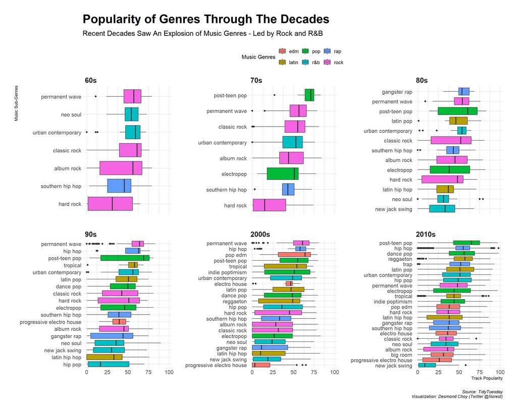

```r
spotify %>%
  group_by(decades, playlist_subgenre) %>%
  add_count(playlist_subgenre) %>%
  filter(n > 5) %>%
  ggplot(aes(
    reorder_within(playlist_subgenre, track_popularity, decades),
    track_popularity
  )) +
  geom_boxplot(aes(fill = playlist_genre)) +
  coord_flip() +
  facet_wrap(decades ~ ., nrow = 2, scales = "free_y") +
  scale_x_reordered() +
  theme_ipsum() +
  labs(
    title = "Popularity of Genres Through The Decades",
    subtitle = "Recent Decades Saw An Explosion of Music Genres - Led by Rock and R&B",
    caption = "\n Source: TidyTuesday
      Visualization: Desmond Choy (Twitter @Norest)",
    fill = "Music Genres",
    x = "Music Sub-Genres",
    y = "Track Popularity"
  ) +
  theme(
    plot.title = element_text(face = "bold", size = 25),
    plot.subtitle = element_text(size = 15),
    strip.background = element_blank(),
    strip.text = element_text(face = "bold", size = 15),
    legend.position = "top",
    legend.title = element_text("Music Genres"),
    legend.box = "horizontal",
    legend.text = element_text(size = 10)
  ) +
  guides(row = guide_legend(nrow = 1))
```

Permanent wave stood out as a rock sub-genre that, until 2010, stood the test of time in terms of popularity.

Trouble is… as an avid music fan, I’ve not heard of this sub-genre permanent wave at all! Still horrified, let me dig into the dataset a little more. I discover permanent wave actually had a few of my all-time favourite artists and I’ve been a closet permanent wave fan all this while!

```r
spotify %>%
  filter(playlist_subgenre == "permanent wave") %>%
  count(track_artist, sort = TRUE)
```

```
# A tibble: 471 × 2
   track_artist              n
   <chr>                 <int>
 1 Muse                     19
 2 The Smiths               19
 3 David Bowie              13
 4 Depeche Mode             12
 5 The Cure                 12
 6 Foo Fighters             11
 7 New Order                11
 8 Red Hot Chili Peppers    11
 9 George Harrison           9
10 Oasis                     9
# ℹ 461 more rows
```

How about some suggestions to danceable EDM tracks that I could listen to when out for a run?

# 4 Most danceable EDM tracks

We filter by Danceability, as defined as *how suitable a track is for dancing based on a combination of musical elements including tempo, rhythm stability, beat strength, and overall regularity. A value of 0.0 is least danceable and 1.0 is most danceable.*

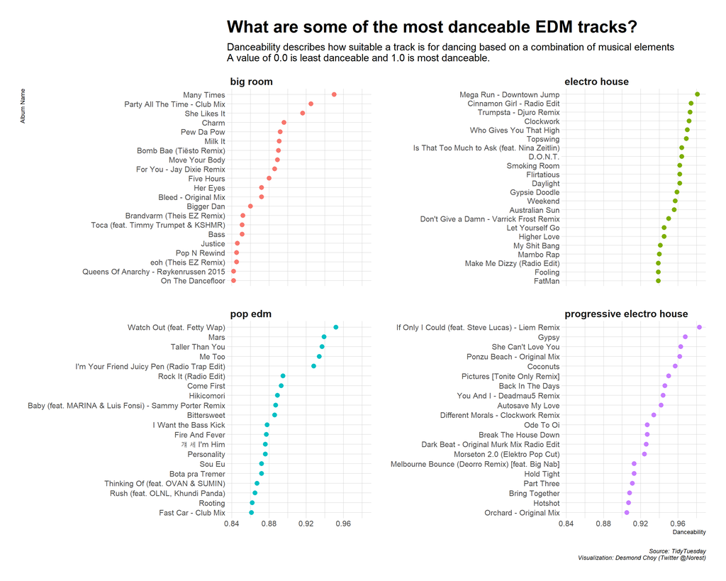

```r
spotify %>%
  select(playlist_genre, playlist_subgenre, track_name, danceability) %>%
  filter(playlist_genre == "edm") %>%
  distinct(track_name, .keep_all = TRUE) %>%
  group_by(playlist_subgenre) %>%
  top_n(n = 20, wt = danceability) %>%
  ggplot(aes(reorder_within(track_name, danceability, playlist_subgenre), danceability)) +
  geom_point(aes(colour = playlist_subgenre), size = 3, show.legend = FALSE) +
  coord_flip() +
  facet_wrap(. ~ playlist_subgenre, nrow = 2, scales = "free_y") +
  scale_x_reordered() +
  theme_ipsum() +
  labs(
    title = "What are some of the most danceable EDM tracks?",
    subtitle = "Danceability describes how suitable a track is for dancing based on a combination of musical elements\nA value of 0.0 is least danceable and 1.0 is most danceable.",
    caption = "\n Source: TidyTuesday
      Visualization: Desmond Choy (Twitter @Norest)",
    fill = "Music Genres",
    x = "Album Name",
    y = "Danceability"
  ) +
  theme(
    plot.title = element_text(face = "bold", size = 25),
    plot.subtitle = element_text(size = 15),
    strip.background = element_blank(),
    strip.text = element_text(face = "bold", size = 15),
    legend.position = "top",
    legend.title = element_text("Music Genres"),
    legend.box = "horizontal",
    legend.text = element_text(size = 10)
  ) +
  guides(row = guide_legend(nrow = 1))
```

# 5 Curating my sub-genres

Finally, how about some curated suggestions - Based on the criteria listed below, what are some suggestions for sub-genres?

- `Instrumentalness`: Predicts whether a track contains no vocals. “Ooh” and “aah” sounds are treated as instrumental in this context. The closer the instrumentalness value is to 1.0, the greater likelihood the track contains no vocal content.
- `Acousticness`: A confidence measure from 0.0 to 1.0 of whether the track is acoustic. 1.0 represents high confidence the track is acoustic.
- `Valence`: A measure from 0.0 to 1.0 describing the musical positiveness conveyed by a track. Tracks with high valence sound more positive (e.g. happy, cheerful, euphoric), while tracks with low valence sound more negative (e.g. sad, depressed, angry).

So my approach was to create a criteria that involved summing up `Instrumentalness`, `Acousticness`, `Valence`. Sub-genres with the highest criteria would then be picked …. right?

```r
spotify %>%
  mutate(criteria = instrumentalness + acousticness + valence) %>%
  select(playlist_genre, playlist_subgenre, track_album_name, criteria) %>%
  distinct(track_album_name, .keep_all = TRUE) %>%
  group_by(playlist_subgenre) %>%
  summarise(criteria = sum(criteria)/n()) %>%
  arrange(desc(criteria))
```

```
# A tibble: 24 × 2
   playlist_subgenre  criteria
   <chr>                 <dbl>
 1 hip hop               1.08
 2 tropical              0.945
 3 reggaeton             0.907
 4 neo soul              0.888
 5 latin pop             0.866
 6 classic rock          0.865
 7 electro house         0.852
 8 hip pop               0.850
 9 urban contemporary    0.830
10 latin hip hop         0.823
# ℹ 14 more rows
```

Hip-hop?? When you think acousticness and instrumental tunes … hip hop doesn’t quite come to mind.

```r
spotify %>%
  mutate(criteria = instrumentalness + acousticness + valence) %>%
  select(playlist_genre, playlist_subgenre, track_artist, track_album_name, criteria) %>%
  distinct(track_album_name, .keep_all = TRUE) %>%
  filter(playlist_subgenre == "hip hop") %>%
  arrange(desc(criteria)) %>%
  head(20)
```

```
# A tibble: 20 × 5
   playlist_genre playlist_subgenre track_artist       track_album_name criteria
   <chr>          <chr>             <chr>              <chr>               <dbl>
 1 rap            hip hop           Goldenninjah       Moods                2.86
 2 rap            hip hop           oofoe              double oo tape       2.73
 3 rap            hip hop           luvwn              sanya                2.70
 4 rap            hip hop           Brenky             Previsão             2.7
 5 rap            hip hop           Bluedoom           4:20 PM              2.66
 6 rap            hip hop           Sarah, the Illstr… Pocket Full of …     2.62
 7 rap            hip hop           Loop Schrauber     Repeat               2.62
 8 rap            hip hop           Chris Keys         Detour               2.62
 9 rap            hip hop           Ymori              Better Things        2.60
10 rap            hip hop           Leavv              essence              2.58
11 rap            hip hop           Flynn              Cycles               2.58
12 rap            hip hop           junyii.            junyii・dr!p         2.52
13 rap            hip hop           Smeyeul.           Bedroom Skits        2.52
14 rap            hip hop           Nathan Kawanishi   Yokohama             2.52
15 rap            hip hop           Brenky             Winter Flakes        2.52
16 rap            hip hop           Chill Children     bob le head          2.49
17 rap            hip hop           Mr Mantega         Fire to Hire         2.44
18 rap            hip hop           jrd.               Reflections          2.43
19 rap            hip hop           David Chief        Sands EP             2.42
20 rap            hip hop           Made in M          Flashlight           2.41
```

I initally thought there was an error in the data or my code. But I picked a few tunes to sample and it turns out I genuinely enjoyed all of them! This was an amazingly fruitful and productive exploration of new music to widen my aural horizons.

Here’s a Top20 playlist below, based on my criteria.

```r
spotify %>%
  mutate(criteria = instrumentalness + acousticness + valence) %>%
  select(playlist_genre, playlist_subgenre, track_artist, track_album_name, criteria) %>%
  distinct(track_album_name, .keep_all = TRUE) %>%
  arrange(desc(criteria)) %>%
  head(20)
```

```
# A tibble: 20 × 5
   playlist_genre playlist_subgenre  track_artist      track_album_name criteria
   <chr>          <chr>              <chr>             <chr>               <dbl>
 1 rap            hip hop            Goldenninjah      Moods                2.86
 2 latin          tropical           Kavv              Cruise Control       2.77
 3 latin          tropical           S-Ilo             Targa                2.73
 4 rap            hip hop            oofoe             double oo tape       2.73
 5 rap            hip hop            luvwn             sanya                2.70
 6 rap            hip hop            Brenky            Previsão             2.7
 7 r&b            urban contemporary Paco de Lucía     La Búsqueda (Re…     2.68
 8 latin          tropical           Reyna Tropical    Como Fuego           2.68
 9 rap            hip hop            Bluedoom          4:20 PM              2.66
10 rock           classic rock       Booker T. & the … Green Onions         2.63
11 rap            hip hop            Sarah, the Illst… Pocket Full of …     2.62
12 rap            hip hop            Loop Schrauber    Repeat               2.62
13 rap            hip hop            Chris Keys        Detour               2.62
14 rap            hip hop            Ymori             Better Things        2.60
15 rap            hip hop            Leavv             essence              2.58
16 rap            hip hop            Flynn             Cycles               2.58
17 r&b            urban contemporary Grey              Goodnight, Univ…     2.57
18 pop            indie poptimism    Joe Corfield      Chillhop Essent…     2.54
19 latin          tropical           S-Ilo             Ascent               2.53
20 rap            hip hop            junyii.           junyii・dr!p         2.52
```

As always, RMarkdown document can be found in my [github](https://github.com/DesmondChoy) should you wish to replicate these results.